# Opponent tendency report

Carolina Panthers offense Scouting report for the Saints · 2026 Week 10 · Panthers at Saints, Sun Nov 15, 2026 Line: NO -1.5 · O/U 48.5 · Model estimate (Elo v1 (cloud)): NO 54% to win (market 50%). Not betting advice. Data through Week 9 (8 games). Only games before this week are used. Ranks are among all 32 teams.

### Roster changes: no in-season trades for CAR

nflverse’s trade feed has nothing after Aug 28, 2025; newer trades come from the hand-kept list and weekly rosters.

### 3 things to know

1. **Red zone:** the NFL’s most pass-heavy, 68% pass rate (league avg 53%). 56 plays
2. **Early downs:** 2nd-most pass-heavy, 64% pass rate (league avg 55%). 328 plays
3. **3rd & 7+:** 4th-most run-heavy, 91% pass rate (league avg 94%). 44 plays

### Early downs: pass-first, throws more than the situation calls for

| Metric | Value | NFL rank | League avg | Last season | Plays |
| --- | --- | --- | --- | --- | --- |
| Pass rate | 64% | 2nd | 55% | 52% (26th) | 328 |
| Pass rate over expected | +7 pts | 2nd | -2 pts | -6 pts (28th) | 328 |
| Shotgun rate | 59% | 12th | 55% | 60% (17th) | 328 |
| EPA per play | +0.11 | 9th | +0.00 | -0.05 (26th) | 328 |

### 3rd & 7+: they throw 91% of the time (league 94%, 4th-most run-heavy)

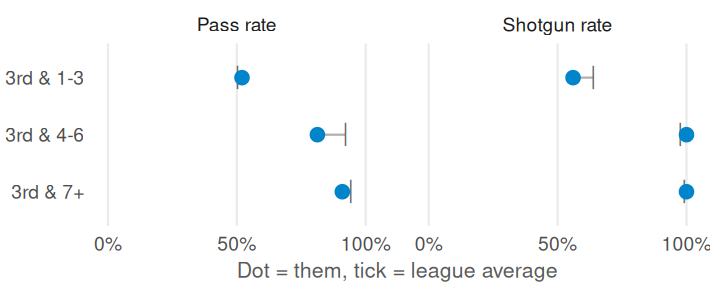

| Distance | Pass rate | EPA/play | Plays |
| --- | --- | --- | --- |
| 3rd & 1-3 | 52% (14th) | -0.56 (32nd) | 25* |
| 3rd & 4-6 | 81% (30th) | -0.16 (24th) | 16* |
| 3rd & 7+ | 91% (29th) | -0.22 (20th) | 44 |

### Red zone: throw-first (68% pass rate)

| Metric | Value | NFL rank | League avg | Last season | Plays |
| --- | --- | --- | --- | --- | --- |
| Pass rate | 68% | 1st | 53% | 58% (9th) | 56 |
| Pass rate over expected | +9 pts | 1st | -5 pts | -2 pts (14th) | 56 |
| EPA per play | +0.20 | 4th | +0.04 | -0.19 (29th) | 56 |

### Tendency shifts: 2 changes in the last 4 games

| Situation | Metric | Season | Last 4 | Change | Plays (last 4) |
| --- | --- | --- | --- | --- | --- |
| Early downs | Pass rate over expected | +7 pts | +6 pts | -1 pts | 153 |
| Early downs | Shotgun rate | 59% | 59% | -0 pts | 153 |
| Early downs | EPA per play | +0.11 | -0.03 | **-0.14** | 153 |
| 3rd & 1-3 | Pass rate | 52% | 42% | -10 pts | 12* |
| Red zone | Pass rate | 68% | 67% | -1 pts | 24* |
| All neutral downs | EPA per play | +0.03 | -0.10 | **-0.13** | 199 |

### Most dangerous: passes on early downs (+0.20 EPA per play vs. +0.07 league)

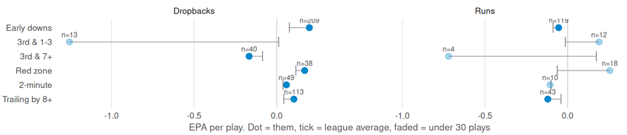

**How to read this.** Pass rate counts sacks and scrambles as passes. *Pass rate over expected* compares their pass rate with what an average team calls in the same down, distance, field position, score and time (nflverse `xpass` model). EPA = expected points added; above 0 is good for the offense. Early downs, 3rd down, red zone and “all neutral” use only plays when the offense’s win probability was 5–95%. The 2-minute and trailing-by-8+ splits use every play. Numbers marked * are under 30 plays: treat them as a hint, not a tendency. Shift = last 4 games differ from the season by 5+ points (0.10 EPA) on 30+ plays. Roster changes lists in-season trades (nflverse trade feed plus a hand-kept list) and other moves seen in weekly rosters; a regular (starting QB, 15%+ of targets, 30%+ of carries, or 60%+ of snaps before the move) is marked ⚠. Data: nflverse play-by-play (nflfastR / nflreadr), openly licensed. Built by Chris Antosiewicz · [source](https://github.com/chrisantosiewicz/nfl-opponent-report).